# Mapping with ggplot

In this notebook, we test out some methods for mapping with ggplot:

# Load packages and set preferences

```r
library(sf)
library(dplyr)
library(ggplot2)

## Load the conflicted package
library(conflicted)
conflict_prefer("filter", "dplyr", quiet = TRUE)
conflict_prefer("count", "dplyr", quiet = TRUE)
conflict_prefer("select", "dplyr", quiet = TRUE)
conflict_prefer("arrange", "dplyr", quiet = TRUE)
```

# Load spatial data

```r
## Define a convenience constant
epsg_geo_wgs84 <- 4326

## City boundary
sf_citybnd_ll <- st_read("./data/sf_citybnd.geojson")
sf_citybnd_ll
```

```
Simple feature collection with 1 feature and 9 fields
Geometry type: POLYGON
Dimension:     XY
Bounding box:  xmin: -122.5151 ymin: 37.70825 xmax: -122.357 ymax: 37.81176
Geodetic CRS:  WGS 84
           NAME CityType Pop2010 Land_sqmi DateIncorp              WebLink        County Notes CityAbbv
1 San Francisco     City  805235     46.87 1850-04-16 http://www.sfgov.org San Francisco  <NA>       SF
                        geometry
1 POLYGON ((-122.3779 37.7083...
```

```r
## City neighborhoods
sf_nb_ll <- st_read(dsn = "./data/sf_nb.geojson")
sf_nb_ll
```

```
Simple feature collection with 41 features and 1 field
Geometry type: MULTIPOLYGON
Dimension:     XY
Bounding box:  xmin: -122.5149 ymin: 37.70813 xmax: -122.357 ymax: 37.8333
Geodetic CRS:  WGS 84
First 10 features:
                            nhood                       geometry
1           Bayview Hunters Point MULTIPOLYGON (((-122.3816 3...
2                  Bernal Heights MULTIPOLYGON (((-122.4036 3...
3             Castro/Upper Market MULTIPOLYGON (((-122.4266 3...
4                       Chinatown MULTIPOLYGON (((-122.4062 3...
5                       Excelsior MULTIPOLYGON (((-122.424 37...
6  Financial District/South Beach MULTIPOLYGON (((-122.3875 3...
7                       Glen Park MULTIPOLYGON (((-122.4474 3...
8                Golden Gate Park MULTIPOLYGON (((-122.4409 3...
9                  Haight Ashbury MULTIPOLYGON (((-122.432 37...
10                   Hayes Valley MULTIPOLYGON (((-122.4208 3...
```

# Our first map with ggplot

Plot the city boundary:

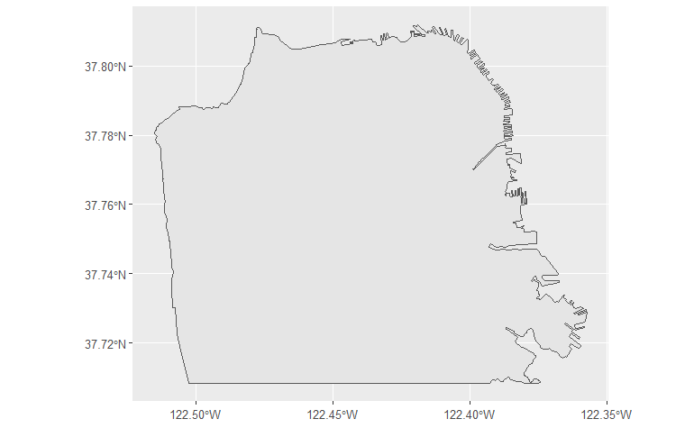

```r
ggplot(sf_citybnd_ll) + geom_sf()
```

Add an additional layer for the neighborhood boundaries:

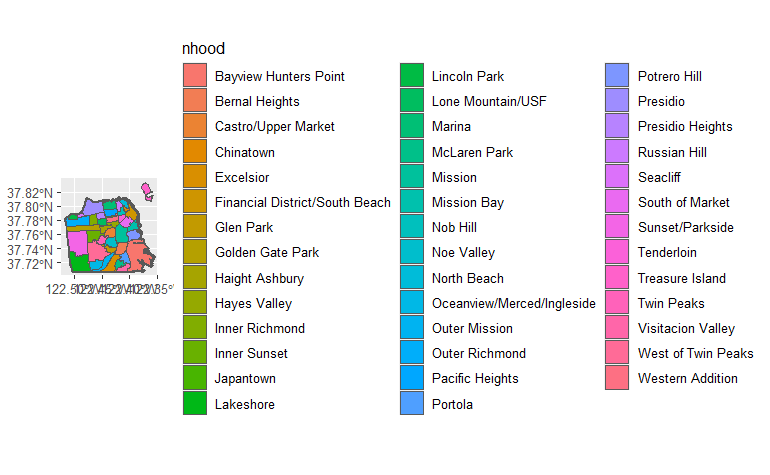

```r
ggplot(sf_citybnd_ll) + geom_sf(lwd=1.2) +
  geom_sf(data = sf_nb_ll, aes(fill = nhood))
```

Get rid of the legend and add a tile:

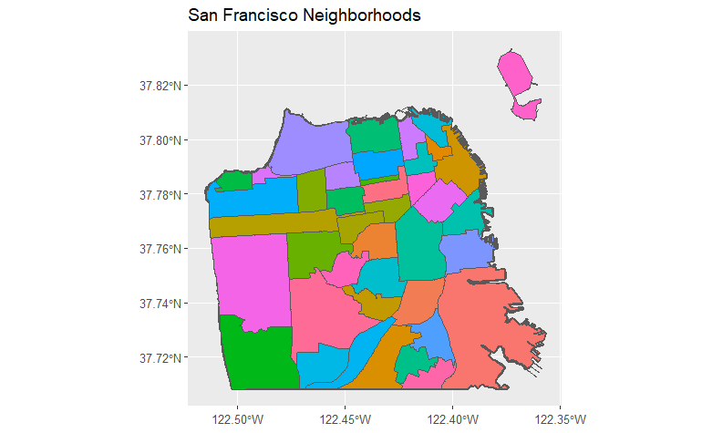

```r
ggplot(sf_citybnd_ll) + geom_sf(lwd=1.2) +
  geom_sf(data = sf_nb_ll, aes(fill = nhood)) +
  theme(legend.position="none") +
  ggtitle("San Francisco Neighborhoods")
```

Add a scale bar and compass (complements of ggspatial):

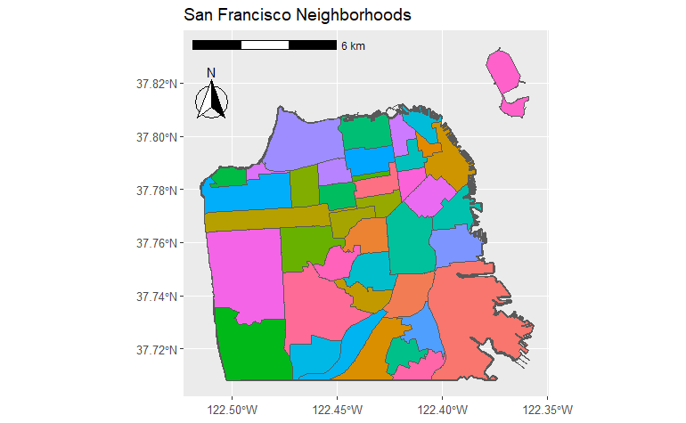

```r
library("ggspatial")
ggplot(sf_citybnd_ll) + geom_sf(lwd=1.2) +
  geom_sf(data = sf_nb_ll, aes(fill = nhood)) +
  theme(legend.position="none") +
  ggtitle("San Francisco Neighborhoods") +
  annotation_scale(location = "tl", width_hint = 0.5) +
  annotation_north_arrow(location = "tl", which_north = "true",
                         pad_x = unit(0, "in"), pad_y = unit(0.4, "in"),
                         style = north_arrow_fancy_orienteering)
```

Add a basemap from Open Street Map:

Note: Zoom determines the amount of detail in the background map. It can vary from 1 (entire world) to 20 (an individual building). For a city, look for Zoom in the range of 10-12.

[output not shown]

[output cut: 45 more lines]

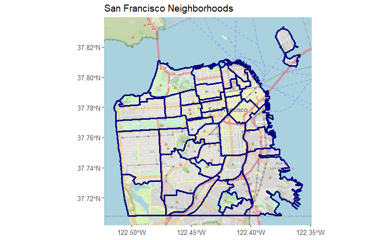

```r
ggplot(sf_citybnd_ll) + geom_sf(lwd=1.2) +
  annotation_map_tile(type = "osm", zoom = 12) +
  geom_sf(data = sf_nb_ll, col = "navy", fill = NA, lwd = 1.1) +
  ggtitle("San Francisco Neighborhoods")
```

Other OSM maps you can use:

```r
rosm::osm.types()
```

```
 [1] "osm"                    "opencycle"              "hotstyle"               "loviniahike"
 [5] "loviniacycle"           "hikebike"               "hillshade"              "osmgrayscale"
 [9] "stamenbw"               "stamenwatercolor"       "osmtransport"           "thunderforestlandscape"
[13] "thunderforestoutdoors"  "cartodark"              "cartolight"
```

YOUR TURN: Try a different base map:

```r
# ggplot(sf_citybnd_ll) + geom_sf(lwd=1.2) +
#   annotation_map_tile(type = "stamenbw", zoom = 12) +
#   geom_sf(data = sf_nb_ll, col = "navy", fill = NA, lwd = 1.1) +
#   ggtitle("San Francisco Neighborhoods")
```

You can also ‘zoom in’ by adding `coord_sf()`. For example to zoom into BayView Hunters Point:

[output not shown]

[output cut: 16 more lines]

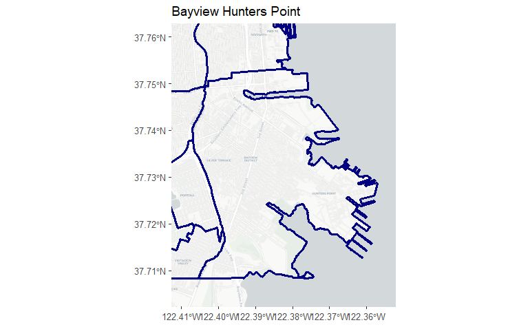

```r
ggplot(sf_citybnd_ll) + geom_sf(lwd=1.2) +
  annotation_map_tile(type = "cartolight", zoom = 14) +
  geom_sf(data = sf_nb_ll, col = "navy", lwd=1.1,  fill = NA) +
  coord_sf(xlim = c(-122.41, -122.355), ylim = c(37.705, 37.76)) +
  ggtitle("Bayview Hunters Point")
```

# Visualize 311 Call Locations

311 is the number (or website) you can call to ask city services to come deal with something. It’s one of the datasets the city makes available on [SFData.org](https://data.sfgov.org/City-Infrastructure/311-Cases/vw6y-z8j6).

## Import 311 Data

The workshop data folder contains a Geopackage with 311 calls from 2021 for street and sidewalk cleaning. We can import it with:

```r
strtswlk_311_sf <- st_read(dsn = "./data/sf_311_strt-sdwk-cln_2021.gpkg")
dim(strtswlk_311_sf)
```

```
[1] 278649      4
```

The data include different types of cleaning requests:

```r
strtswlk_311_sf$service_subtype %>% table()
```

```
.
                           Automotive                           Bulky Items                        Christmas_tree
                                  374                                106464                                  3010
         City_garbage_can_overflowing                      General Cleaning                   Hazardous Materials
                                17190                                105762                                  9585
                Human or Animal Waste                         Medical Waste      Missed_Route_Mechanical_Sweeping
                                30049                                  3921                                   420
Missed_TrashRecycleCompost_Collection  Street and Sidewalk Cleaning Request              Transit_shelter_platform
                                  108                                     6                                  1760
```

278,000 is a lot of points for a map! Let’s just plot requests to clean up Bulky Items:

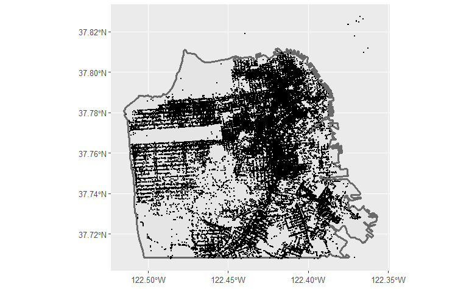

```r
strtswlk_bulky_sf <- strtswlk_311_sf %>% filter(service_subtype == "Bulky Items")

ggplot(sf_citybnd_ll) + geom_sf(lwd=1.2, col = "dimgray") +
  geom_sf(data = strtswlk_bulky_sf, cex = 0.3)
```

## Bin the data

Because there are so many points, we need a visualization strategy that avoids ‘overplotting’ (i.e., laying points on top of each other). There are several options to deal with overplotting. The first option we’ll demonstrate is simply binning the data into grid cells and visualizing the number of calls per cell.

ggplot2 provides a 2d binning function called geom_bin_2d(). The only problem is this geom doesn’t know who to handle sf objects - it wants a data frame. So step 1 is to construct a data frame with the longitude and latitude coordinates:

```r
stswlk_bulky_df  <- strtswlk_bulky_sf %>% st_coordinates() %>% as.data.frame()
glimpse(stswlk_bulky_df)
```

```
Rows: 106,464
Columns: 2
$ X <dbl> -122.4077, -122.4021, -122.4175, -122.4148, -122.4164, -122.4181, -122.4180, -122.4020, -122.4155, -122.3999, -~
$ Y <dbl> 37.75634, 37.72406, 37.77323, 37.75422, 37.75394, 37.75399, 37.75397, 37.72118, 37.71554, 37.71662, 37.72730, 3~
```

Now we can feed this into `geom_bin_2d()`:

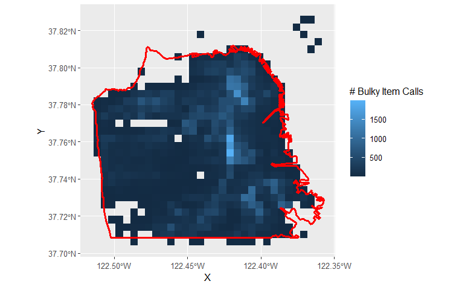

```r
ggplot() +
  geom_bin_2d(data = stswlk_bulky_df, aes(x = X, y = Y), stat = "bin2d") +
  geom_sf(data = sf_citybnd_ll, lwd=1.2, col = "red", fill = NA) +
  labs(fill = "# Bulky Item Calls")
```

## Contours

A second approach is to create contours of the density of calls. ggplot provides `geom_density_2d()` for this purpose. To speed performance a bit, we’ll plot a random sample of the entire set of points:

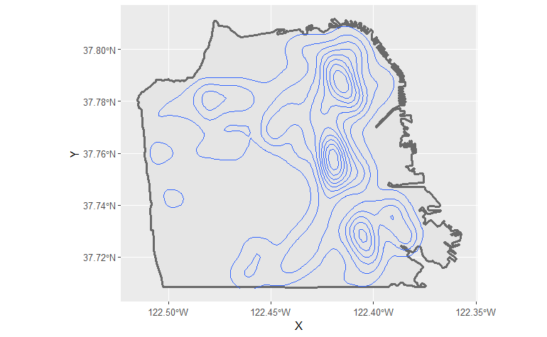

```r
stswlk_samp_bulky_df <- stswlk_bulky_df %>% sample_n(10000)

ggplot(sf_citybnd_ll) + geom_sf(lwd=1.2, col = "dimgray") +
  geom_density_2d(data = stswlk_samp_bulky_df, aes(x = X, y = Y))
```

To make the contours, `geom_density_2d()` generates a Kernal Density Estimator (KDE) surface, which is a raster layer showing the density of points per unit area. a KDE surface is similar to binning the data, however it also applies a smoothing function.

### Add a legend to our contour plot

To create the legend, we should add `color` to our aes() function, and tell it which variable to use. While we’re at it, we can get rid of the axes labels:

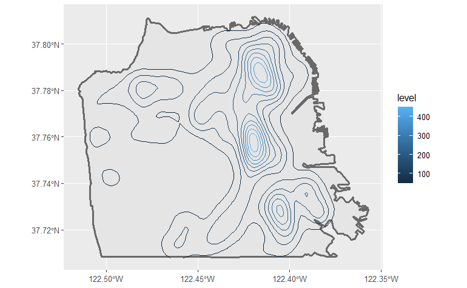

```r
ggplot(sf_citybnd_ll) + geom_sf(lwd=1.2, col = "dimgray") +
  geom_density_2d(data = stswlk_samp_bulky_df,
                  aes(x = X, y = Y, color = ..level..)) +
  theme(axis.title=element_blank())
```

To make the colors stand out a bit more, we can change the color scale:

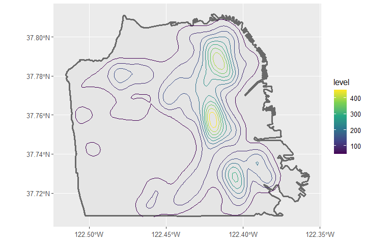

```r
ggplot(sf_citybnd_ll) + geom_sf(lwd=1.2, col = "dimgray") +
  geom_density_2d(data = stswlk_samp_bulky_df,
                  aes(x = X, y = Y, color = stat(level))) +
  theme(axis.title=element_blank()) +
  scale_color_viridis_c()
```

Better yet, we can also add a filled version of the contour bands:

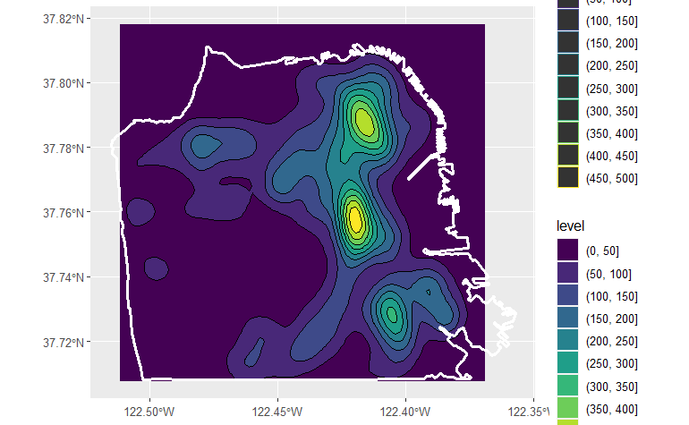

```r
ggplot() +
  geom_density_2d_filled(data = stswlk_samp_bulky_df,
                 aes(x = X, y = Y, color = stat(level))) +
  geom_density_2d(data = stswlk_samp_bulky_df,
                  aes(x = X, y = Y),
                  color = "black") +
  geom_sf(data = sf_citybnd_ll, lwd=1, col = "white", fill = NA) +
  theme(axis.title=element_blank())
```

We have two legends going on - one for the fill colors and one for the contour lines (which are all black). We can suppress the legend for the contour lines with `guides()`:

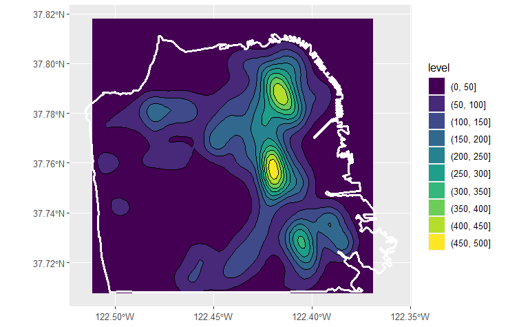

```r
ggplot() +
  geom_density_2d_filled(data = stswlk_samp_bulky_df,
                 aes(x = X, y = Y, color = stat(level))) +
  geom_density_2d(data = stswlk_samp_bulky_df,
                  aes(x = X, y = Y),
                  color = "black") +
  geom_sf(data = sf_citybnd_ll, lwd=1, col = "white", fill = NA) +
  theme(axis.title=element_blank()) +
  guides(color = FALSE)
```

The contour lines show the density of 311 calls per unit of map area. Those are a bit hard to interpret. We can normalize the density to 0..1 by specifying a different contour variable:

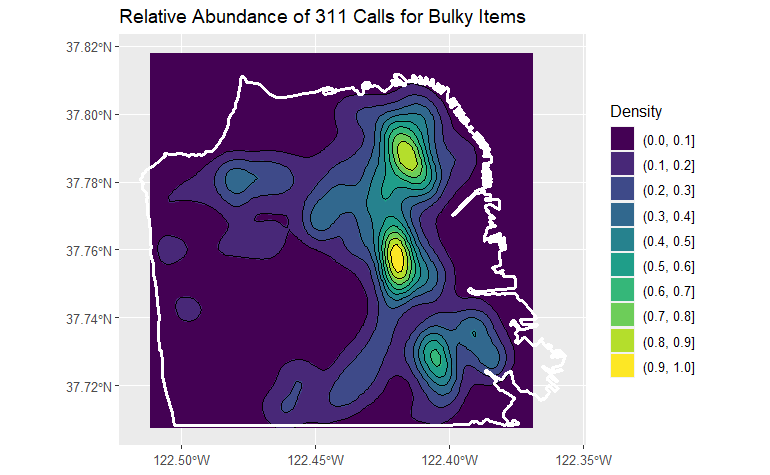

```r
ggplot() +
  geom_density_2d_filled(data = stswlk_samp_bulky_df,
                         contour_var = "ndensity",
                         aes(x = X, y = Y, color = stat(level))) +
  geom_density_2d(data = stswlk_samp_bulky_df,
                  aes(x = X, y = Y),
                  color = "black") +
  geom_sf(data = sf_citybnd_ll, lwd=1, col = "white", fill = NA) +
  theme(axis.title=element_blank()) +
  labs(fill = "Density") +
  ggtitle("Relative Abundance of 311 Calls for Bulky Items") +
  guides(color = FALSE)
```

The map above is ok except for the solid fill of of the lowest level. There are a few ways to improve that like making the alpha layer

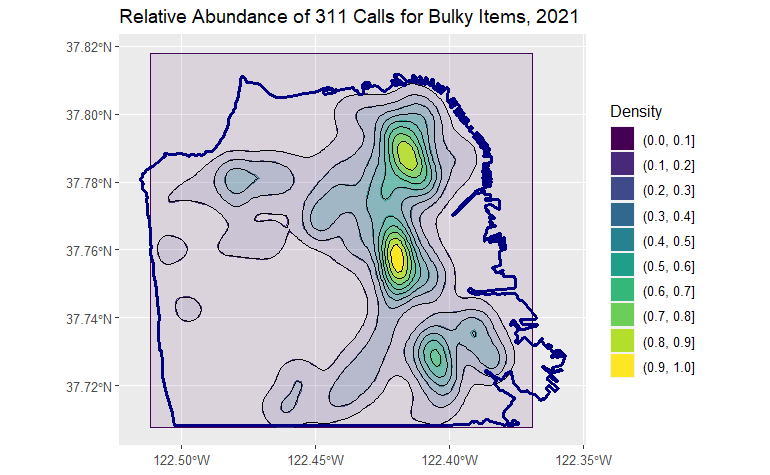

```r
ggplot() +
  geom_density_2d_filled(data = stswlk_samp_bulky_df,
                         contour_var = "ndensity",
                         aes(x = X, y = Y, color = stat(level), alpha = stat(level))) +
  geom_density_2d(data = stswlk_samp_bulky_df,
                  aes(x = X, y = Y),
                  color = "black") +
  geom_sf(data = sf_citybnd_ll, lwd=1, col = "navy", fill = NA) +
  labs(fill = "Density") +
  ggtitle("Relative Abundance of 311 Calls for Bulky Items, 2021") +
  guides(color = FALSE, alpha = FALSE) +
  theme(axis.title=element_blank())
```

## Draw the Contours with a Polygon Geom

The last method we’ll show to deal with overplotting is similar to above, but we’ll display the contour lines as polygons instead of 2d_density contours. What’s the difference you ask? The polygon geom has more options that we can modify.

To draw the KDE contours as polygons, we have to turn to the “stat” version of geom_density_2d(), which is stat_density_2d(). Both of these are actually just wrappers for ggplot2::layer, so its not as radical as it might seem. The stat version computes the KDE contours, but also allows us to pick the geom to use to draw the contours.

[output not shown]

[output cut: 47 more lines]

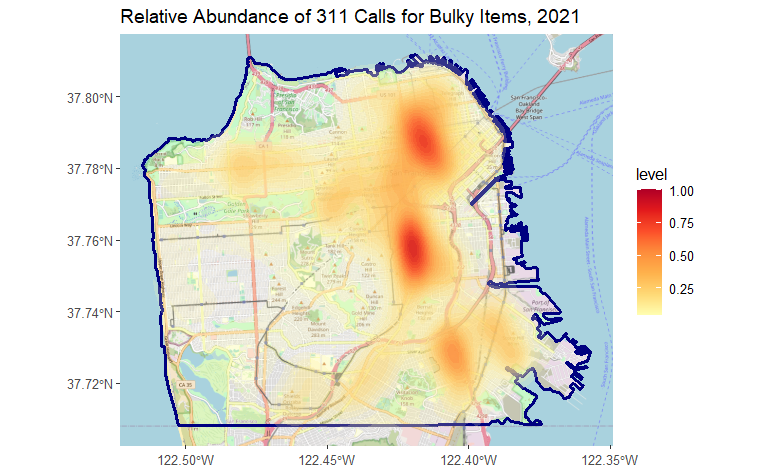

```r
library(RColorBrewer)

ggplot(data = sf_citybnd_ll) +
  annotation_map_tile(type = "osm", zoom = 13) +
  geom_sf(data = sf_citybnd_ll, lwd=1, col = "navy", fill = NA) +
  stat_density_2d(data = stswlk_samp_bulky_df,
                  geom = "polygon",
                  contour_var = "ndensity",
                  aes(x = X, y = Y, fill = stat(level)),
                  n=c(100,200),
                  alpha = 0.2,
                  bins = 25) +
  scale_fill_gradientn(colors = brewer.pal(7, "YlOrRd")) +
  theme(axis.title=element_blank()) +
  ggtitle("Relative Abundance of 311 Calls for Bulky Items, 2021")
```

Other values you could use for the color ramp:

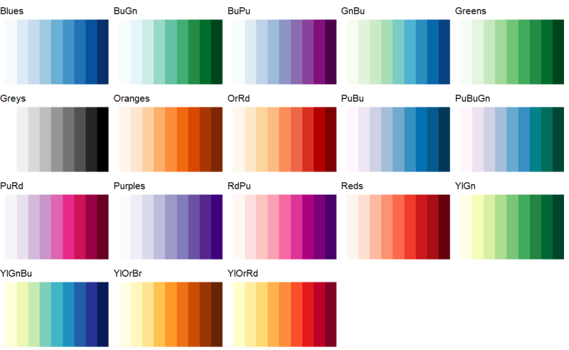

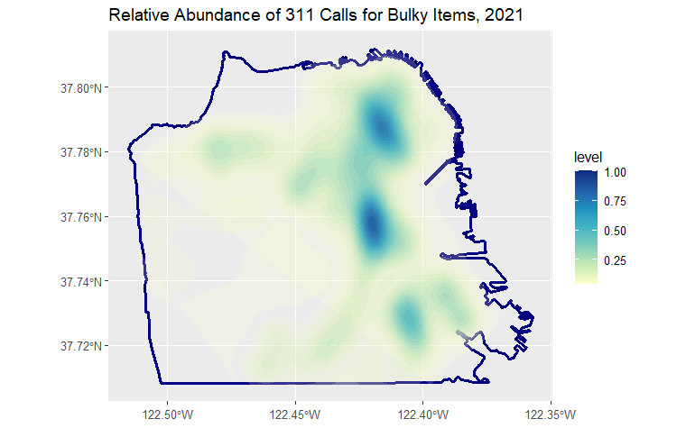

```r
ggplot() +
  geom_sf(data = sf_citybnd_ll, lwd=1, col = "navy", fill = NA) +
  stat_density_2d(data = stswlk_samp_bulky_df,
                  geom = "polygon",
                  contour_var = "ndensity",
                  aes(x = X, y = Y, fill = stat(level)),
                  n=c(100,200),
                  alpha = 0.2,
                  bins = 25) +
  scale_fill_gradientn(colors = brewer.pal(7, "YlGnBu")) +
  theme(axis.title=element_blank()) +
  ggtitle("Relative Abundance of 311 Calls for Bulky Items, 2021")
```

Lastly, let’s make a separate heat maps for each subtype of service. We have to first go back to the full data frame and pull out the coordinates:

```r
stswlk_coords_df  <- strtswlk_311_sf %>%
  mutate(long = st_coordinates(.)[,2],
         lat = st_coordinates(.)[,1]) %>%
  st_drop_geometry() %>%
  select(requested_date, service_subtype, long, lat) %>%
  filter(service_subtype %in% c("Bulky Items", "General Cleaning", "City_garbage_can_overflowing", "Human or Animal Waste"))

glimpse(stswlk_coords_df)
```

```
Rows: 259,465
Columns: 4
$ requested_date  <date> 2021-01-01, 2021-01-01, 2021-01-01, 2021-01-01, 2021-01-01, 2021-01-01, 2021-01-01, 2021-01-01, ~
$ service_subtype <chr> "Human or Animal Waste", "General Cleaning", "Human or Animal Waste", "General Cleaning", "Genera~
$ long            <dbl> 37.75872, 37.78038, 37.78927, 37.79825, 37.75723, 37.72995, 37.75844, 37.75842, 37.78063, 37.7781~
$ lat             <dbl> -122.4197, -122.4075, -122.4159, -122.4104, -122.4069, -122.4100, -122.4198, -122.4197, -122.4797~
```

Now can use the service subtype column to create facets of the data:

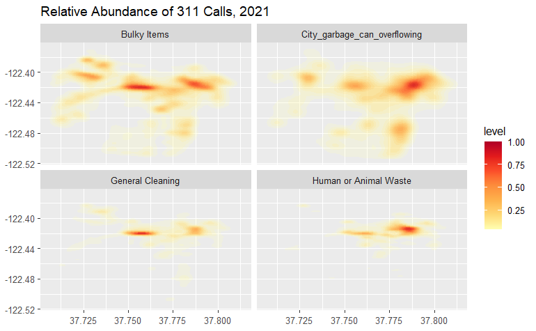

```r
ggplot() +
  stat_density_2d(data = stswlk_coords_df,
                  geom = "polygon",
                  contour_var = "ndensity",
                  aes(x = long, y = lat, fill = stat(level)),
                  n=c(100,200),
                  alpha = 0.2,
                  bins = 25) +
  scale_fill_gradientn(colors = brewer.pal(7, "YlOrRd")) +
  theme(axis.title=element_blank()) +
  ggtitle("Relative Abundance of 311 Calls, 2021") +
  facet_wrap( ~ service_subtype)
```

```r
  # geom_sf(data = sf_citybnd_ll, lwd=1, col = "navy", fill = NA) ## MESSES UP THE EXTENT, USE FORTIFY()
```